# Investigate_a_Dataset

## Exploratory Data Analysis

**During the exploration, I face a new problem. There are duplicate movies. The chart below shows this problem. So I will return to the cleaning step to handle this problem. I decided to keep the first row and drop the others**

[figure not shown]

```python
#Cleaning duplication of the Movies name
# I decided to keep the first row and drop the others
Movies.drop_duplicates(subset='movie_name', keep="first",inplace=True)

#test if it works
Movies.sort_values(by='revenue',ascending=False).head()
```

|  | popularity | revenue | movie_name | genres | vote_average | year |
| --- | --- | --- | --- | --- | --- | --- |
| 1386 | 9.432768 | 2.781506e+09 | Avatar | Action\|Adventure\|Fantasy\|Science Fiction | 7.1 | 2009 |
| 3 | 11.173104 | 2.068178e+09 | Star Wars: The Force Awakens | Action\|Adventure\|Science Fiction\|Fantasy | 7.5 | 2015 |
| 4361 | 7.637767 | 1.519558e+09 | The Avengers | Science Fiction\|Action\|Adventure | 7.3 | 2012 |
| 0 | 32.985763 | 1.513529e+09 | Jurassic World | Action\|Adventure\|Science Fiction\|Thriller | 6.5 | 2015 |
| 4 | 9.335014 | 1.506249e+09 | Furious 7 | Action\|Crime\|Thriller | 7.3 | 2015 |

[figure not shown]

**General questions:**  
1. What is the trend of the total number of movies over the generations?  
2. What's the revenue trend over the generations?

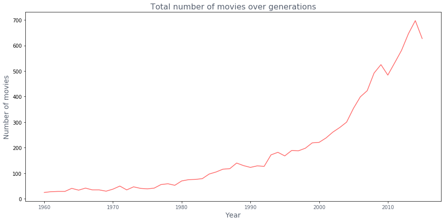

```python
# Plot total number of movies by generations
Movies_per_year = Movies.groupby(['year']).count()['movie_name']

plt.figure(figsize=(15,7))
plt.plot(Movies_per_year,color="#ff6b6b")
plt.title('Total number of movies over generations',fontsize=16,color='#57606f')
plt.xlabel('Year',fontsize=14,color='#57606f')
plt.ylabel('Number of movies',fontsize=14,color='#57606f')
plt.xticks(color='#57606f')
plt.show()
```

The number of movies increases by generations. I think this relationship is logical. Almost all industries are improving over the years. The reason for this is the technology revolution which is inflated flexibility of work and quality and creates new channels. In the past, movies need a great deal of effort to produce the black, white and silent film (this amazing movie have a story about it https://www.themoviedb.org/movie/44826-hugo?language=en-US). Now, you can see a lot of movies across your tablet set on your bed.

[figure not shown]

There is an important point in the chart there is a decrease in the number of films in 2010. One of the possible reasons is the dataset have not enough data this year.

[figure not shown]

**What's the revenue trend over the generations?**

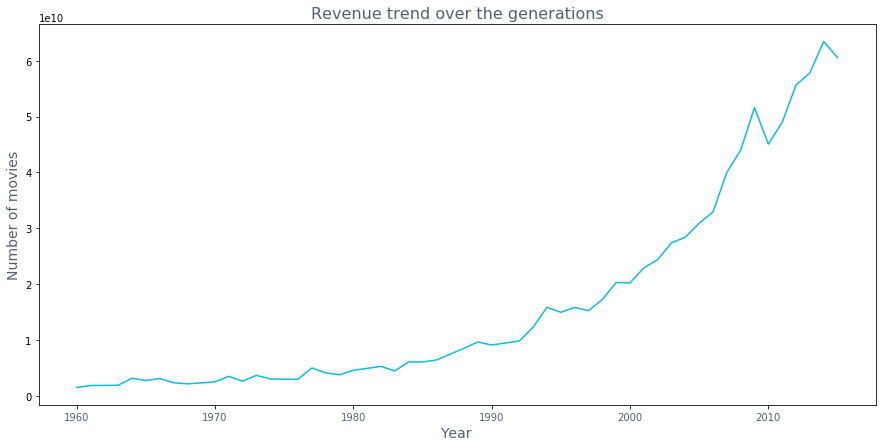

```python
#What's the revenue trend over the ?
revenue_year = Movies.groupby(['year']).sum()['revenue']

plt.figure(figsize=(15,7))
plt.plot(revenue_year,color='#0abde3')
plt.title('Revenue trend over the generations',fontsize=16,color='#57606f')
plt.xlabel('Year',fontsize=14,color='#57606f')
plt.ylabel('Number of movies',fontsize=14,color='#57606f')
plt.xticks(color='#57606f')
plt.show()
```

Increase revenues over generations. This relationship is also logical. Because the number of movies also increases.

[figure not shown]

**What are properties that associated with high revenue Movies?**  
1. What are the top 20 Movies based on revenue?  
2. High movies revenue Vs popularity.  
3. High revenue Movies Vs voting rate.

```python
#What is the top 20 movies based on revenue?
# useful link (http://cmdlinetips.com/2018/02/how-to-sort-pandas-dataframe-by-columns-and-row/)

#Subset of top 20 Movies based on revenue
Revenue_top = Movies.sort_values(by='revenue',ascending=False).head(20)
Revenue_top.head(20)
```

|  | popularity | revenue | movie_name | genres | vote_average | year |
| --- | --- | --- | --- | --- | --- | --- |
| 1386 | 9.432768 | 2.781506e+09 | Avatar | Action\|Adventure\|Fantasy\|Science Fiction | 7.1 | 2009 |
| 3 | 11.173104 | 2.068178e+09 | Star Wars: The Force Awakens | Action\|Adventure\|Science Fiction\|Fantasy | 7.5 | 2015 |
| 4361 | 7.637767 | 1.519558e+09 | The Avengers | Science Fiction\|Action\|Adventure | 7.3 | 2012 |
| 0 | 32.985763 | 1.513529e+09 | Jurassic World | Action\|Adventure\|Science Fiction\|Thriller | 6.5 | 2015 |
| 4 | 9.335014 | 1.506249e+09 | Furious 7 | Action\|Crime\|Thriller | 7.3 | 2015 |
| 14 | 5.944927 | 1.405036e+09 | Avengers: Age of Ultron | Action\|Adventure\|Science Fiction | 7.4 | 2015 |
| 3374 | 5.711315 | 1.327818e+09 | Harry Potter and the Deathly Hallows: Part 2 | Adventure\|Family\|Fantasy | 7.7 | 2011 |
| 1586 | 0.475826 | 1.262886e+09 | Beauty and the Beast | Fantasy | 5.6 | 2009 |
| 5425 | 4.946136 | 1.215440e+09 | Iron Man 3 | Action\|Adventure\|Science Fiction | 6.9 | 2013 |
| 8 | 7.404165 | 1.156731e+09 | Minions | Family\|Animation\|Adventure\|Comedy | 6.5 | 2015 |
| 3522 | 0.760503 | 1.123747e+09 | Transformers: Dark of the Moon | Action\|Science Fiction\|Adventure | 6.1 | 2011 |
| 4949 | 7.122455 | 1.118889e+09 | The Lord of the Rings: The Return of the King | Adventure\|Fantasy\|Action | 7.9 | 2003 |
| 4365 | 5.603587 | 1.108561e+09 | Skyfall | Action\|Adventure\|Thriller | 6.8 | 2012 |
| 8094 | 1.136610 | 1.106280e+09 | The Net | Crime\|Drama\|Mystery\|Thriller\|Action | 5.6 | 1995 |
| 4363 | 6.591277 | 1.081041e+09 | The Dark Knight Rises | Action\|Crime\|Drama\|Thriller | 7.5 | 2012 |
| 6555 | 4.205992 | 1.065660e+09 | Pirates of the Caribbean: Dead Man's Chest | Adventure\|Fantasy\|Action | 6.8 | 2006 |
| 1930 | 2.711136 | 1.063172e+09 | Toy Story 3 | Animation\|Family\|Comedy | 7.5 | 2010 |
| 1921 | 5.572950 | 1.025491e+09 | Alice in Wonderland | Family\|Fantasy\|Adventure | 6.3 | 2010 |
| 3375 | 4.955130 | 1.021683e+09 | Pirates of the Caribbean: On Stranger Tides | Adventure\|Action\|Fantasy | 6.3 | 2011 |
| 4367 | 4.218933 | 1.017004e+09 | The Hobbit: An Unexpected Journey | Adventure\|Fantasy\|Action | 6.9 | 2012 |

```python
# This function plot a bar graph by sending columns and the figure colors
def plot_bar(dataset,col1,col2,title,color1,color2):

    #sort values
    df_c = dataset.sort_values(col2)

    #Figure size
    plt.figure(figsize=(20,13))

    #Bar plot
    x = df_c[col2]
    y = range(len(df_c[col2]))
    plt.barh(y,x, align='center',
            color=[color1,color2])

    #Bar plot properties
    plt.title(title,fontsize=30,color='#485460')

    #Labels
    plt.xlabel(col2,fontsize=25,color='#485460')
    plt.ylabel(col1,fontsize=25,color='#485460')
    plt.yticks(np.arange(len(df_c[col1])),df_c[col1],color='#485460',fontsize=20)
    plt.xticks(fontsize=20)
    plt.show()
```

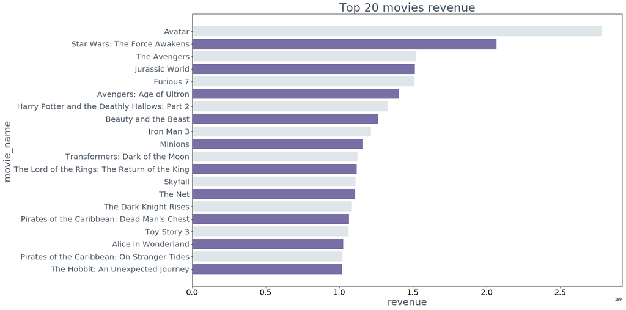

```python
# Plot a bar chart display top 20 Movies name
# you send the dataset,column1(y),column2(x),title of the graph,color1,color2

# I use 2 colors to make the graph more readable
plot_bar(Revenue_top,'movie_name','revenue','Top 20 movies revenue','#786fa6','#dfe6e9')
```

[output not shown]

[figure not shown]

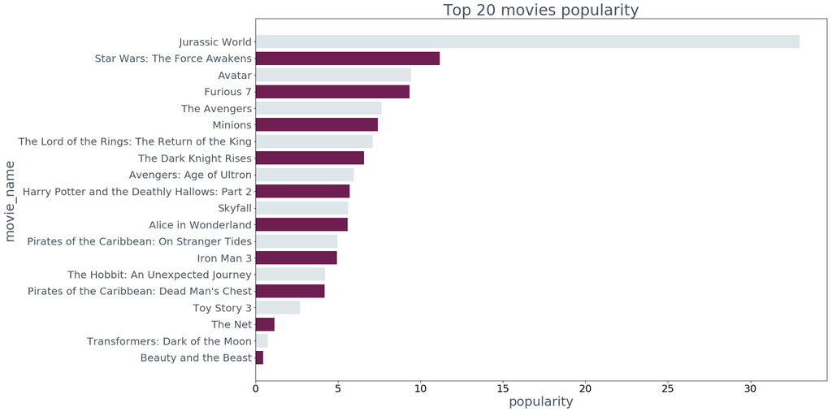

```python
#High movies revenue Vs popularity
plot_bar(Revenue_top,'movie_name','popularity','Top 20 movies popularity','#6F1E51','#dfe6e9')
```

Revenue is not necessarily affected by popularity. Because the site calculates its own audience. There are multi-website that does the same thing as IMDB and rotten tomatoes. Also what if the movie was added after the show by the long time the user maybe don't visit the page or favorite it. If this scenario doesn't appear maybe the users favorite the movie as a part of there memory or a preferable movie.

[figure not shown]

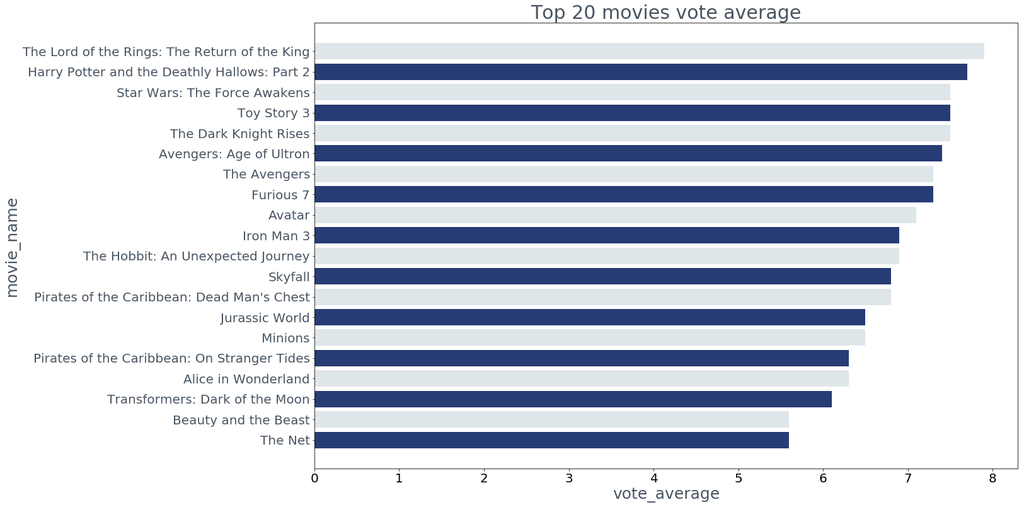

```python
#High revenue Movies Vs voting rate.
plot_bar(Revenue_top,'movie_name','vote_average','Top 20 movies vote average','#273c75','#dfe6e9')
```

[output not shown]

[figure not shown]

**Which genres are the most popular over the generations?**

```python
#Q1) Which genres are the most popular over the generations??

# Extract genres list
# This is a useful links
# https://stackoverflow.com/questions/41190422/pandas-split-a-column-on-delimiter-and-get-unique-values
# https://stackoverflow.com/questions/19392226/attributeerror-dataframe-object-has-no-attribute
# https://medium.com/@rtjeannier/pandas-101-cont-9d061cb73bfc


split_genrese = Movies['genres'].str.split('|', expand=True)
genres = pd.unique(split_genrese.stack())

year = Movies['year'].unique()
year.sort(axis=0)
print(year)

# Count the genres frequancy
count = pd.value_counts(split_genrese.values.flatten())

# Greate now I should sum the popularity for each genres grouped it by year
genre_popularity = pd.DataFrame({'genre': genres,'2010':0,'2011':0,'2012':0,'2013':0,'2014':0,'2015':0})
print(type(genre_popularity))
```

```
[1960 1961 1962 1963 1964 1965 1966 1967 1968 1969 1970 1971 1972 1973 1974
 1975 1976 1977 1978 1979 1980 1981 1982 1983 1984 1985 1986 1987 1988 1989
 1990 1991 1992 1993 1994 1995 1996 1997 1998 1999 2000 2001 2002 2003 2004
 2005 2006 2007 2008 2009 2010 2011 2012 2013 2014 2015]
<class 'pandas.core.frame.DataFrame'>
```

```python
# Useful link (https://medium.com/@rtjeannier/pandas-101-cont-9d061cb73bfc)

#Fill the popularity fo each genry
genre_popularity = pd.DataFrame({'genre': genres,1960:0,1970:0,1980:0,1990:0,2000:0,2010:0})



for i,value in Movies['genres'].iteritems():
    for g,p in genre_popularity['genre'].iteritems():
        if value == p:
            if  (Movies['year'].loc[i] >= 1960) and (Movies['year'].loc[i] <= 1969):
                genre_popularity[1960].loc[g] += Movies['popularity'].loc[i]

            elif  (Movies['year'].loc[i] >= 1970) and (Movies['year'].loc[i] <= 1979):
                genre_popularity[1970].loc[g] += Movies['popularity'].loc[i]

            elif  (Movies['year'].loc[i] >= 1980) and (Movies['year'].loc[i] <= 1989):
                genre_popularity[1980].loc[g] += Movies['popularity'].loc[i]

            elif  (Movies['year'].loc[i] >= 1990) and (Movies['year'].loc[i] <= 1999):
                genre_popularity[1990].loc[g] += Movies['popularity'].loc[i]

            elif  (Movies['year'].loc[i] >= 2000) and (Movies['year'].loc[i] <= 2009):
                genre_popularity[2000].loc[g] += Movies['popularity'].loc[i]

            elif  (Movies['year'].loc[i] >= 2010) and (Movies['year'].loc[i] <= 2019):
                genre_popularity[2010].loc[g] += Movies['popularity'].loc[i]
```

```python
genre_popularity.head()
```

|  | genre | 1960 | 1970 | 1980 | 1990 | 2000 | 2010 |
| --- | --- | --- | --- | --- | --- | --- | --- |
| 0 | Action | 0.000000 | 0.126723 | 2.182794 | 1.063002 | 14.602510 | 19.294962 |
| 1 | Adventure | 0.000000 | 0.000000 | 1.247333 | 4.422967 | 3.083300 | 5.535303 |
| 2 | Science Fiction | 1.131402 | 0.114062 | 2.120826 | 3.447578 | 2.228401 | 3.591147 |
| 3 | Thriller | 1.143560 | 0.522601 | 0.000000 | 3.326565 | 7.227164 | 40.541297 |
| 4 | Fantasy | 0.057243 | 0.000000 | 1.178524 | 3.062771 | 0.475826 | 0.911367 |

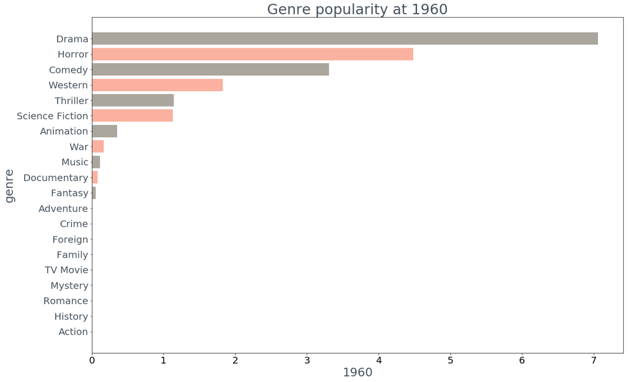

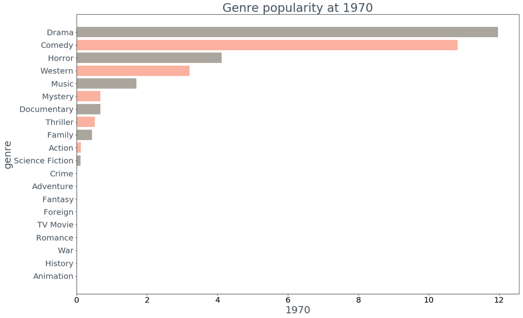

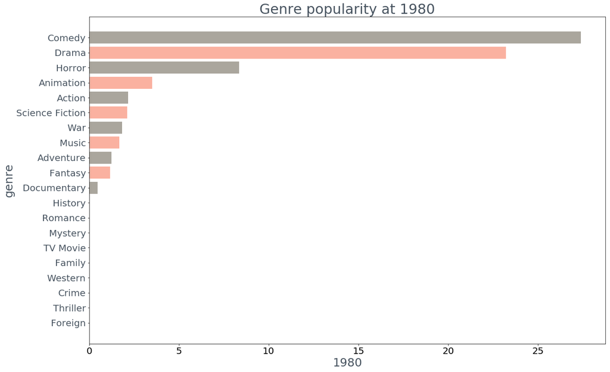

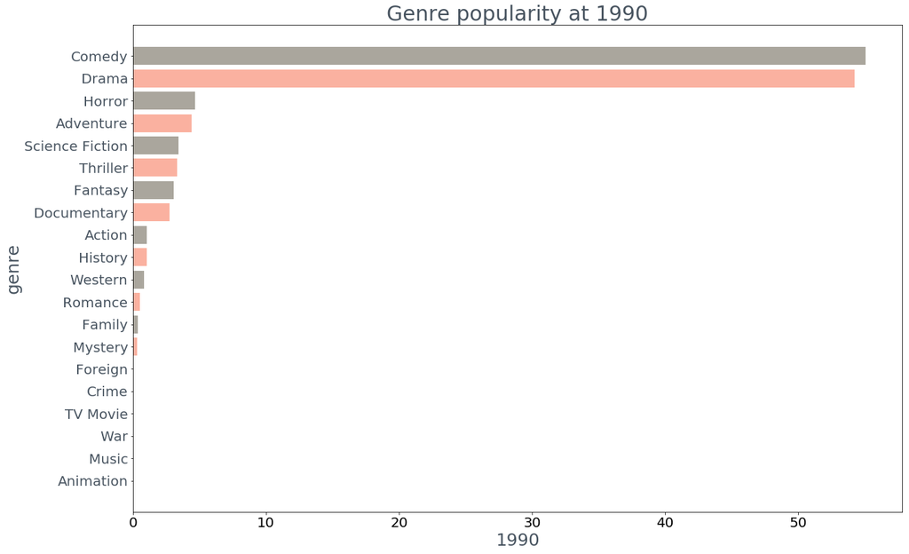

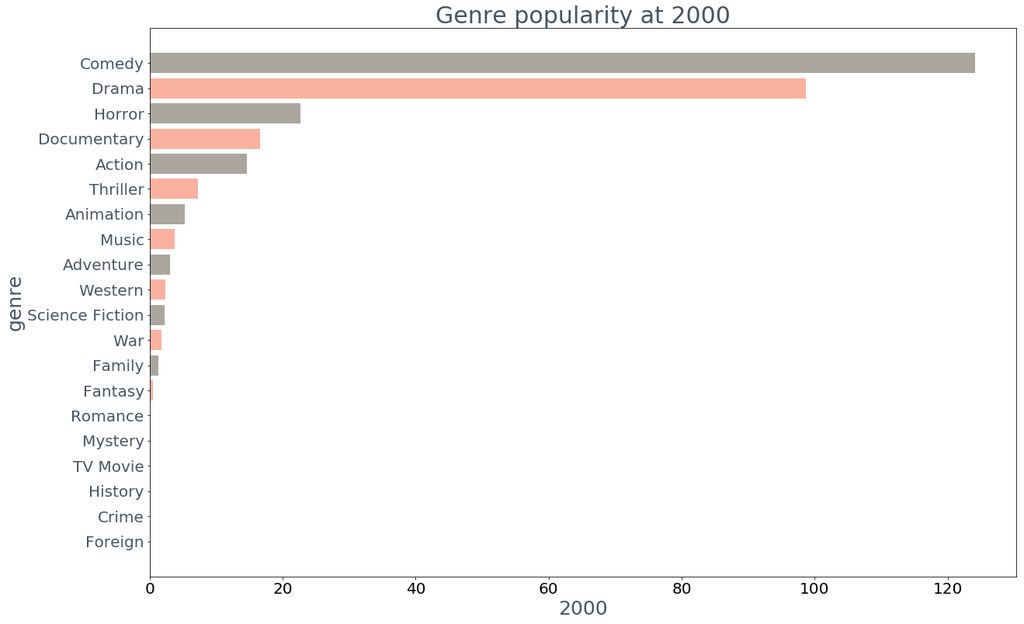

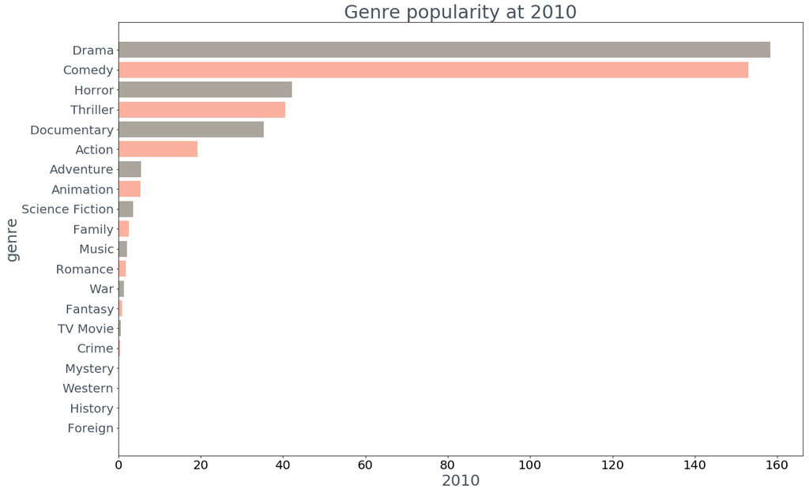

```python
#Frist I will take the column name
x_ax = list(genre_popularity.columns.values)

# Then remove genre
x_ax.remove("genre")


#for loop to plot

title = "Genre popularity at "
for x in x_ax:
    plot_bar(genre_popularity,'genre',x,title+str(x),'#fab1a0','#aaa69d')
```

The horror movies placed at third after the 70s and still there until 2010s.

[figure not shown]

## Conclusions

[figure not shown]

```python
from subprocess import call
call(['python', '-m', 'nbconvert', 'Investigate_a_Dataset.ipynb'])
```

```
0
```